# Analysis of US Rock climbing data

After extracting and cleaning OpenBeta's export of Mountain Projects database of rock climbs within the US (https://github.com/OpenBeta/climbing-data), further cleaning of the data was required to obtain a clean, workable file for analysis (see data_preparation.ipynb). The final result was saved under Data_final.xslx.

In this document we aim to look at the spread of sport climbing routes across various US states. While the analysis is mainly focused on getting a better understanding of the discipline of sport climbing, we will also take a look at other disciplines and their prevelance.

A quick explanation of the three main disciplines of rock climbing discussed in this report:

**Sport climbing** involves ascending a rock face using pre-placed bolts for protection, **trad (traditional) climbing** requires climbers to place their own removable gear for protection, and **bouldering** involves climbing shorter rock formations without ropes, typically only a few meters high and with portable soft mattresses to protect any falls.

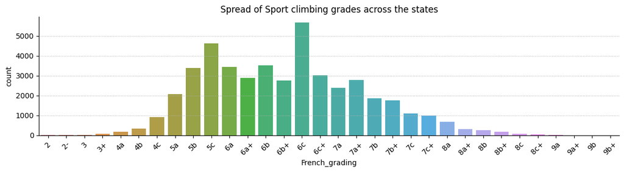

In the graph above we can see that most sport climbing routes in the US are graded between 5a and 7b. This is expected, as it corresponds to the average difficulty from beginner to intermediate. Routes graded 7b or harder are considered difficult. In the following we want to plot the same distribution but by states individually to get quickly get a more high level overview for each state.

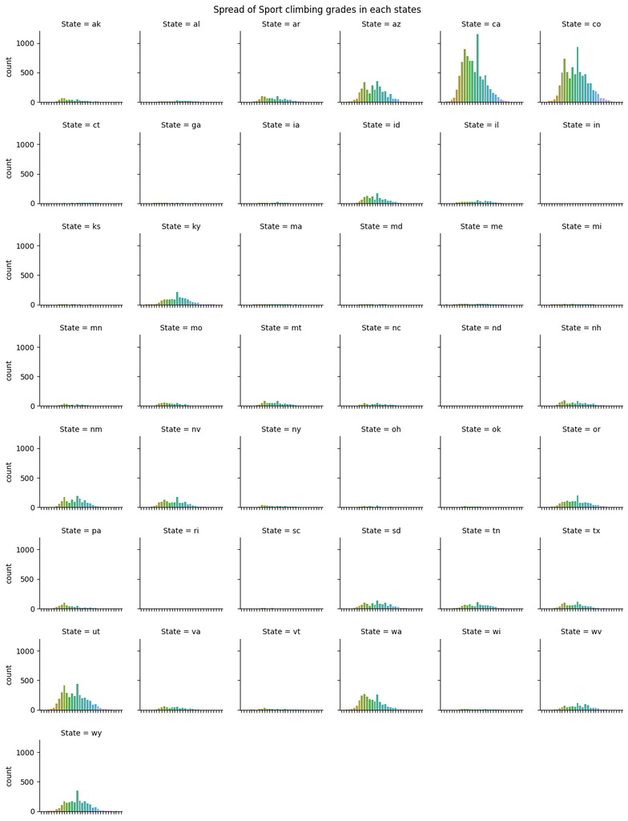

Since we did plot the spread of sport routes in each state without normalization to the states we can make the observation that the distribution or quantity of sport climbing routes across the different states is quite heterogeneous. In the following we want to get a more comprehensive overview of that finding by plotting the total count of sport routes in every state as well as the states proportion (%) of all sport routes in the US.

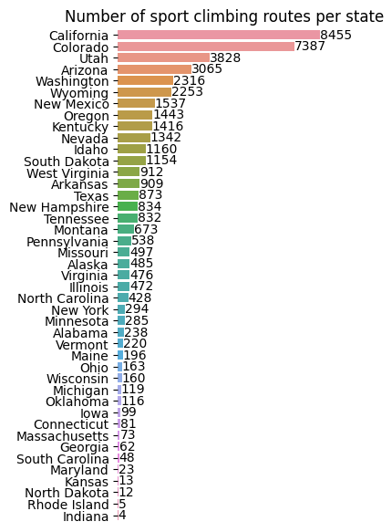

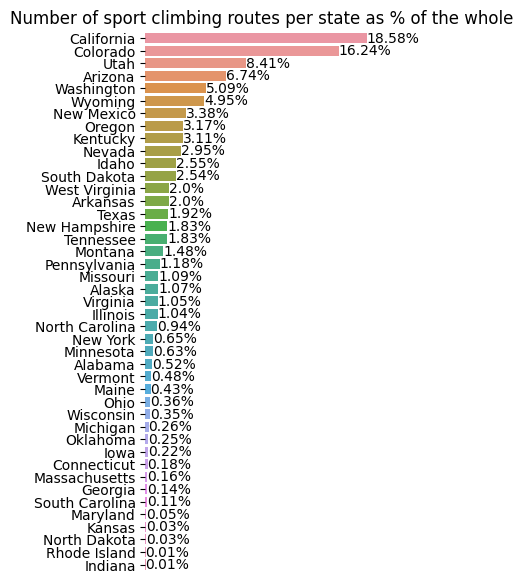

Because states are vastly different in size, lets look at the density of sport climbing routes within each state to have a more normalized comparison. Therefore we use data on size obtained from: https://statesymbolsusa.org/symbol-official-item/national-us/uncategorized/states-size. We then merged the data on state size to our data of sport climbing routes and normalized the number of sport routes to the size of the state. A sample of the dataset is shown in the table below. The data is sorted by the Number of sport routes per sqkm.

|  | State | State size (sqM) | Nr. of Sport routes | Sport routes/sqkm |
| --- | --- | --- | --- | --- |
| 1 | New Hampshire | 8969 | 834 | 0.238047 |
| 2 | Colorado | 103730 | 7387 | 0.182307 |
| 3 | California | 155973 | 8455 | 0.138773 |
| 4 | Utah | 82168 | 3828 | 0.119264 |
| 5 | West Virginia | 24087 | 912 | 0.096929 |
| 6 | Kentucky | 39732 | 1416 | 0.091235 |
| 7 | Washington | 66582 | 2316 | 0.089047 |
| 8 | Arizona | 113642 | 3065 | 0.069045 |
| 9 | Vermont | 9249 | 220 | 0.060893 |
| 10 | Wyoming | 97105 | 2253 | 0.059396 |

Plotting the density of sport climbing routes across states while keeping the order of the states following the total number of sport climbs per state, paints a different picture. New Hampshire, while by far not having the most sport climbing routes, has the densest spread of routes across the state. This is likely due to the relatively small size of the state but its possession of the White Mountains and Lakes Region. After New Hampshire, California, Colorado and Utah are still leading the charts.

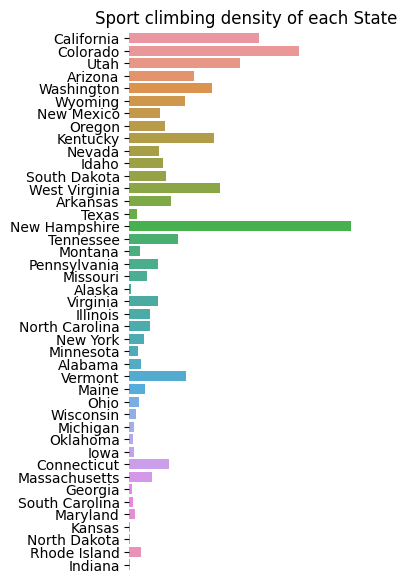

Now that we looked at the distribution of sport climbing routes across states, we want to dig into the more difficult routes. In the States, at the time this data was extracted, there were 1569 sport routes graded 8a or harder and only 21 routes graded 9a or harder. This makes up 3.44 % of all sport routes. A list of the number of hard sport routes in the 20 State that hold the most is shown below. The mean percentage of hard routes in each State is 5.8 % as visualized by the violin plot.

|  | State | Count of Hard Routes | % of the States total |
| --- | --- | --- | --- |
| 0 | Colorado | 523 | 7.08 |
| 1 | California | 328 | 3.88 |
| 2 | Utah | 235 | 6.14 |
| 3 | Wyoming | 155 | 6.88 |
| 4 | Arizona | 144 | 4.7 |
| 5 | Oregon | 132 | 9.15 |
| 6 | Kentucky | 88 | 6.21 |
| 7 | South Dakota | 85 | 7.37 |
| 8 | Nevada | 85 | 6.33 |
| 9 | Washington | 82 | 3.54 |
| 10 | West Virginia | 80 | 8.77 |
| 11 | New Hampshire | 71 | 8.51 |
| 12 | New Mexico | 69 | 4.49 |
| 13 | Tennessee | 54 | 6.49 |
| 14 | Arkansas | 50 | 5.5 |
| 15 | Idaho | 44 | 3.79 |
| 16 | Illinois | 39 | 8.26 |
| 17 | Texas | 37 | 4.24 |
| 18 | Alabama | 28 | 11.76 |
| 19 | Montana | 26 | 3.86 |
| 20 | Minnesota | 24 | 8.42 |

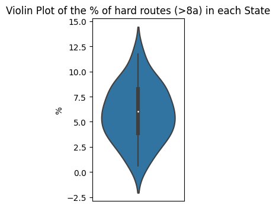

Since some areas and the states in general are more known for trad climbing rather than sport climbing, due to places like Yosemity Valley, it is of interest to compare the prevelance of these two dispcipline. Below we want to plot a heatmap showing the distribution of climbing styles in each state. We ignore Toprope, Ice or Mixed climbing since these disciplines are generally to be assumed fewer than trad, sport or bouldering and not the disciplines we are interested in. For our analysis we also want to focus only on states that have more than a total of 1000 routes across the three disciplines sport, boulder and trad climbing. An alphabeteically sorted table of the prevalence of each discipline in each state is shown in the table below.

| State_name_full | trad | boulder | sport | total | trad_per | boulder_per | sport_per |
| --- | --- | --- | --- | --- | --- | --- | --- |
| Alabama | 167 | 788 | 238 | 1193 | 13 | 66 | 19 |
| Alaska | 622 | 280 | 504 | 1406 | 44 | 19 | 35 |
| Arizona | 2722 | 2164 | 3065 | 7951 | 34 | 27 | 38 |
| Arkansas | 344 | 628 | 909 | 1881 | 18 | 33 | 48 |
| California | 10946 | 10261 | 8462 | 29669 | 36 | 34 | 28 |
| Colorado | 7242 | 6753 | 7464 | 21459 | 33 | 31 | 34 |
| Connecticut | 461 | 1143 | 81 | 1685 | 27 | 67 | 4 |
| Idaho | 632 | 594 | 1161 | 2387 | 26 | 24 | 48 |
| Illinois | 233 | 531 | 472 | 1236 | 18 | 42 | 38 |
| Kentucky | 556 | 191 | 1416 | 2163 | 25 | 8 | 65 |
| Maryland | 412 | 714 | 23 | 1149 | 35 | 62 | 2 |
| Massachusetts | 239 | 3157 | 74 | 3470 | 6 | 90 | 2 |
| Minnesota | 332 | 770 | 313 | 1415 | 23 | 54 | 22 |
| Missouri | 123 | 587 | 499 | 1209 | 10 | 48 | 41 |
| Montana | 498 | 510 | 688 | 1696 | 29 | 30 | 40 |
| Nevada | 1244 | 684 | 1342 | 3270 | 38 | 20 | 41 |
| New Hampshire | 1730 | 2044 | 845 | 4619 | 37 | 44 | 18 |
| New Mexico | 1100 | 843 | 1540 | 3483 | 31 | 24 | 44 |
| New York | 1823 | 1140 | 300 | 3263 | 55 | 34 | 9 |
| North Carolina | 1171 | 756 | 428 | 2355 | 49 | 32 | 18 |
| Ohio | 91 | 1126 | 163 | 1380 | 6 | 81 | 11 |
| Oklahoma | 348 | 644 | 116 | 1108 | 31 | 58 | 10 |
| Oregon | 769 | 509 | 1445 | 2723 | 28 | 18 | 53 |
| Pennsylvania | 323 | 1494 | 542 | 2359 | 13 | 63 | 22 |
| Rhode Island | 4 | 1142 | 5 | 1151 | 0 | 99 | 0 |
| South Dakota | 778 | 804 | 1159 | 2741 | 28 | 29 | 42 |
| Tennessee | 497 | 589 | 832 | 1918 | 25 | 30 | 43 |
| Texas | 191 | 1445 | 873 | 2509 | 7 | 57 | 34 |
| Utah | 4182 | 2898 | 3852 | 10932 | 38 | 26 | 35 |
| Vermont | 306 | 904 | 220 | 1430 | 21 | 63 | 15 |
| Virginia | 522 | 3009 | 476 | 4007 | 13 | 75 | 11 |
| Washington | 1794 | 1696 | 2361 | 5851 | 30 | 28 | 40 |
| West Virginia | 851 | 1081 | 912 | 2844 | 29 | 38 | 32 |
| Wisconsin | 946 | 2343 | 161 | 3450 | 27 | 67 | 4 |
| Wyoming | 1270 | 570 | 2262 | 4102 | 30 | 13 | 55 |
| Average across states | 1299 | 1565 | 1292 | 4156 | 27 | 44 | 29 |
| Sum across states | 45469 | 54792 | 45203 | 145464 | 932 | 1552 | 1016 |

To allow for easier comparison within each state rather than across states we also calcuted the fraction of each states discipline of the states total routes, as already shown in the table above. This is important since a heatmap of total numbers of routes across all states would not be very meaningful. To compare a states spread of disciplines to other states, we want the values to be normalized per state. Therefore we plot the fraction of each discipline instead of total numbers.

[output not shown]

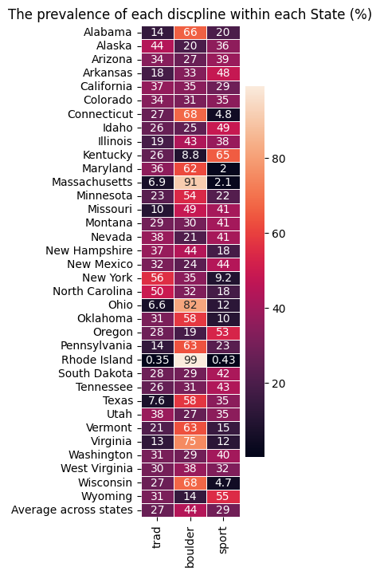

## Summary

As a result of the analysis we have made the following observations:

*Distribution of rock climbs across states:*

- California and Colorado have by far the most sport climbing routes followed by Utah, Arizona, Washington and Wyoming
- Considering the size of the states, New Hampshire has the densest spread of sport climbing routes
- Bouldering is the most common type of rock climbing in the US considering only number of routes

*Sport grades:*

If a person wants to move to a state with a high prevalence of rock climbing routes California, Colorado, New Hampshire or Utah are their best bet. If a person is mainly interested in bouldering, other states like Massachusetts, Pennsylvania or Rhode Island would be of interest too.

## Disclaimer

Finally, it is important to note that this data set and analysis has limitations and can not be taken at face value but merely provide an estimate of the real situation.

- We assume the extracted dataset on GitHub to be complete which might not be the case
- The datset was extracted 3 years ago, so latest numbers are likely to differ
- The dataset is relying on entries on the website MountainProject, which might be incomplete or hold routes that do not exist.